# 1. IMPORTING LIBRARIES

Here, we shall import all the required libraries to perform operations for data

```python
import numpy as np
import pandas as pd
import scipy.stats as stats
import matplotlib.pyplot as plt
import seaborn as sns

import matplotlib.pyplot as plt
%matplotlib inline
sns.set(color_codes=True)
import warnings
warnings.filterwarnings("ignore")
from sklearn import preprocessing
from sklearn import metrics
from sklearn.linear_model import LogisticRegression
from sklearn.neighbors import KNeighborsClassifier
from sklearn.naive_bayes import GaussianNB
from sklearn.metrics import classification_report
from sklearn import svm
from sklearn.utils import resample
from sklearn.metrics import roc_auc_score
from sklearn.metrics import auc
from sklearn.model_selection import GridSearchCV
```

# 2. Reading Data

We read the csv file given into a dataframe

```python
data=pd.read_csv('Bank_Personal_Loan_Modelling.csv')
```

```python
print('The shape of the data is',data.shape)
```

```
The shape of the data is (5000, 14)
```

# 3. EXPLORATORY DATA ANALYSIS

```python
print('the data type of each attribute is : ')
print(" "*50)
data.info()
```

```
the data type of each attribute is :

<class 'pandas.core.frame.DataFrame'>
RangeIndex: 5000 entries, 0 to 4999
Data columns (total 14 columns):
ID                    5000 non-null int64
Age                   5000 non-null int64
Experience            5000 non-null int64
Income                5000 non-null int64
ZIP Code              5000 non-null int64
Family                5000 non-null int64
CCAvg                 5000 non-null float64
Education             5000 non-null int64
Mortgage              5000 non-null int64
Personal Loan         5000 non-null int64
Securities Account    5000 non-null int64
CD Account            5000 non-null int64
Online                5000 non-null int64
CreditCard            5000 non-null int64
dtypes: float64(1), int64(13)
memory usage: 547.0 KB
```

# 3.1 Checking the presence of missing values

```python
data.isnull().sum()
```

```
ID                    0
Age                   0
Experience            0
Income                0
ZIP Code              0
Family                0
CCAvg                 0
Education             0
Mortgage              0
Personal Loan         0
Securities Account    0
CD Account            0
Online                0
CreditCard            0
dtype: int64
```

```python
null=data[data.isnull().any(1)]
print(null)
```

```
Empty DataFrame
Columns: [ID, Age, Experience, Income, ZIP Code, Family, CCAvg, Education, Mortgage, Personal Loan, Securities Account, CD Account, Online, CreditCard]
Index: []
```

# 3.2 5-POINT SUMMARY

```python
data.describe().T
```

|  | count | mean | std | min | 25% | 50% | 75% | max |
| --- | --- | --- | --- | --- | --- | --- | --- | --- |
| ID | 5000.0 | 2500.500000 | 1443.520003 | 1.0 | 1250.75 | 2500.5 | 3750.25 | 5000.0 |
| Age | 5000.0 | 45.338400 | 11.463166 | 23.0 | 35.00 | 45.0 | 55.00 | 67.0 |
| Experience | 5000.0 | 20.104600 | 11.467954 | -3.0 | 10.00 | 20.0 | 30.00 | 43.0 |
| Income | 5000.0 | 73.774200 | 46.033729 | 8.0 | 39.00 | 64.0 | 98.00 | 224.0 |
| ZIP Code | 5000.0 | 93152.503000 | 2121.852197 | 9307.0 | 91911.00 | 93437.0 | 94608.00 | 96651.0 |
| Family | 5000.0 | 2.396400 | 1.147663 | 1.0 | 1.00 | 2.0 | 3.00 | 4.0 |
| CCAvg | 5000.0 | 1.937938 | 1.747659 | 0.0 | 0.70 | 1.5 | 2.50 | 10.0 |
| Education | 5000.0 | 1.881000 | 0.839869 | 1.0 | 1.00 | 2.0 | 3.00 | 3.0 |
| Mortgage | 5000.0 | 56.498800 | 101.713802 | 0.0 | 0.00 | 0.0 | 101.00 | 635.0 |
| Personal Loan | 5000.0 | 0.096000 | 0.294621 | 0.0 | 0.00 | 0.0 | 0.00 | 1.0 |
| Securities Account | 5000.0 | 0.104400 | 0.305809 | 0.0 | 0.00 | 0.0 | 0.00 | 1.0 |
| CD Account | 5000.0 | 0.060400 | 0.238250 | 0.0 | 0.00 | 0.0 | 0.00 | 1.0 |
| Online | 5000.0 | 0.596800 | 0.490589 | 0.0 | 0.00 | 1.0 | 1.00 | 1.0 |
| CreditCard | 5000.0 | 0.294000 | 0.455637 | 0.0 | 0.00 | 0.0 | 1.00 | 1.0 |

# 3.3 UNDERSTANDING THE ATTRIBUTES OF DATA

# 3.3.0 PAIR PLOT

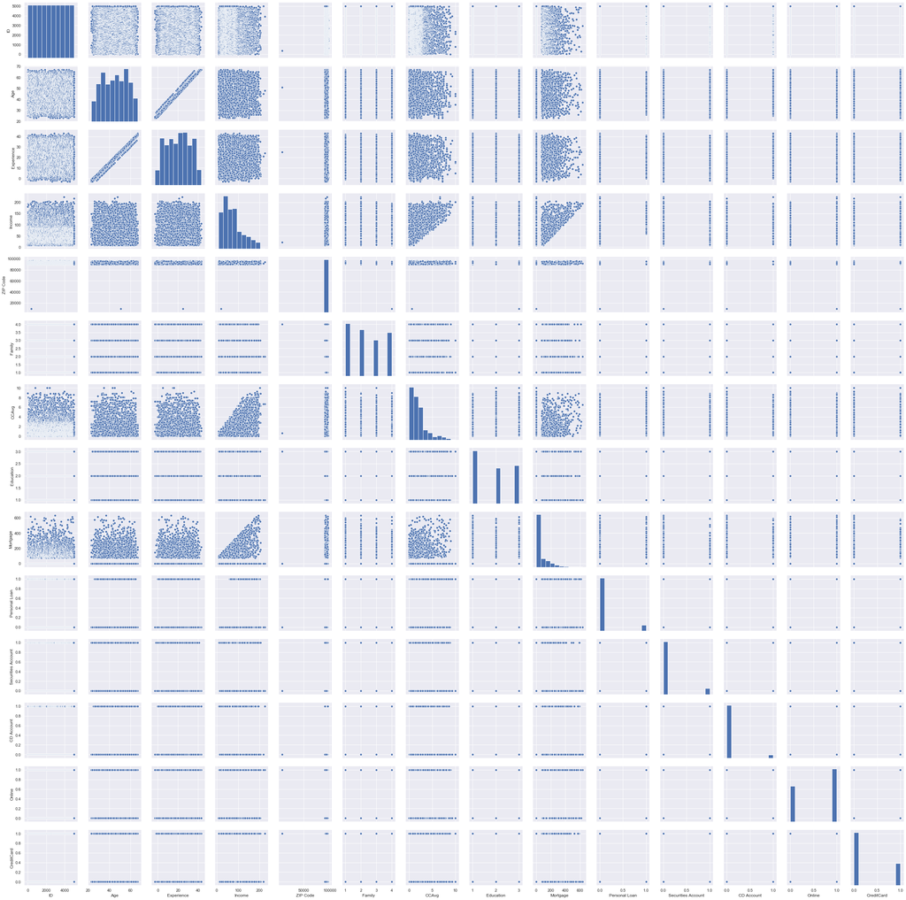

```python
sns.pairplot(data)
```

Observation:

- Age and Experience are linearly related

# 3.3.1 ID

# 3.3.2 AGE

This column is about the age of customer

```python
print("The 5 point summary of age column would give the below results: ")
data['Age'].describe().T
```

```
The 5 point summary of age column would give the below results:
```

```
count    5000.000000
mean       45.338400
std        11.463166
min        23.000000
25%        35.000000
50%        45.000000
75%        55.000000
max        67.000000
Name: Age, dtype: float64
```

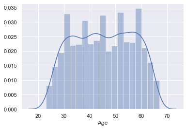

```python
sns.distplot(data['Age'])
```

Since visualisation is not clearly interpretable, lets do a countplot

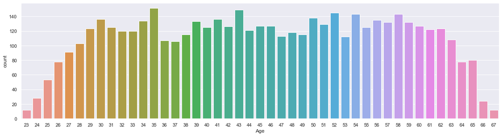

```python
plt.figure(figsize=(20,5))
sns.countplot(data['Age'])
```

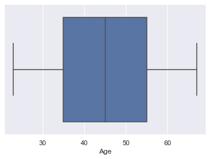

```python
sns.boxplot(data['Age'])
```

Observation:

```python
data['Age'].describe()
```

```
count    5000.000000
mean       45.338400
std        11.463166
min        23.000000
25%        35.000000
50%        45.000000
75%        55.000000
max        67.000000
Name: Age, dtype: float64
```

Observation:

- Here, in age column mean is approximately equal to the median value

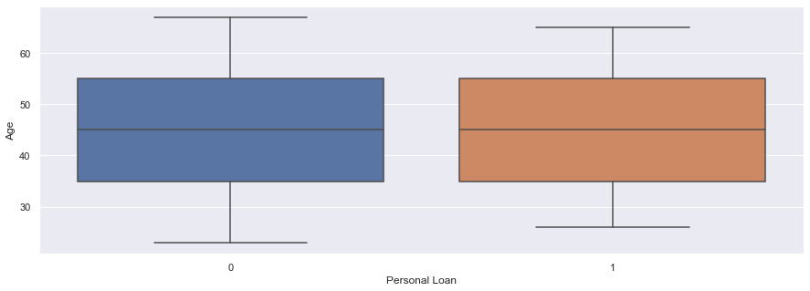

```python
plt.figure(figsize=(15,5))
sns.boxplot(y=data['Age'],x=data['Personal Loan'])
```

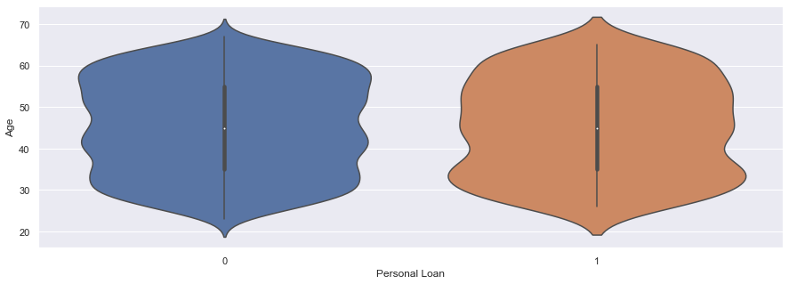

```python
plt.figure(figsize=(15,5))
sns.violinplot(y=data['Age'],x=data['Personal Loan'])
```

Lets do statistical analysis whether age is related to buying Personal Loan or not.Question: Is age related to buying personal loan ?

```python
print("Individual count of bmi column: "," "*500, data['Age'].value_counts())
```

```
Individual count of bmi column:                                                                                                                                                                                                                                                                             …
43    149
52    145
58    143
54    143
50    138
41    136
30    136
56    135
34    134
39    133
59    132
57    132
51    129
60    127
```

[output cut: 31 more lines]

NULL HYPOTHESIS(H0): Age is not related in buying Personal Loan

ALTERNATIVE HYPOTHESIS(Ha): Age is related in buying Personal Loan

# Level of significance = 0.05

```python
null = 'Age is not related in buying Personal Loan'
alternate = 'Age is related in buying Personal Loan'
a=np.array(data[data['Personal Loan']==0].Age)
b=np.array(data[data['Personal Loan']==1].Age)
t_stat, p_value = stats.ttest_ind(a,b,axis=0)
print("the caluclated value of tstatistic is",t_stat)
print("The pvalue is",p_value)
print(""*1000)
print("Based on the statistical evidence")
if p_value > 0.05:
    print("we fail to reject null hypothesis as the p_value", p_value, "is greater than 0.05")
    print(null)
else:
    print("we reject null hypothesis as the p_value", p_value, "is less than 0.05")
    print(alternate)
```

```
the caluclated value of tstatistic is 0.5461906615539323
The pvalue is 0.584959263705325

Based on the statistical evidence
we fail to reject null hypothesis as the p_value 0.584959263705325 is greater than 0.05
Age is not related in buying Personal Loan
```

# 3.3.3 EXPERIENCE

```python
print("The 5 point summary of experience column would give the below results: ")
data['Experience'].describe().T
```

```
The 5 point summary of experience column would give the below results:
```

```
count    5000.000000
mean       20.104600
std        11.467954
min        -3.000000
25%        10.000000
50%        20.000000
75%        30.000000
max        43.000000
Name: Experience, dtype: float64
```

There are negative experience points and this can be seen as the minimum value is -3. Lets explore what are the points which have negative experience

```python
median=data['Experience'].median()
print(median)
```

```
20.0
```

```python
a=data[data['Experience']<0]['Experience'].count()
print("No of records with negative experience",a)
```

```
No of records with negative experience 52
```

```python
negid=data[data['Experience']<0]['ID'].tolist()
for i in negid:
    data.loc[data.loc[np.where(data['ID']==i)].index, 'Experience']=median
```

```python
print("After Replacing with median, The 5 point summary of experience column would give the below results: ")
data['Experience'].describe().T
```

```
After Replacing with median, The 5 point summary of experience column would give the below results:
```

```
count    5000.000000
mean       20.327600
std        11.253035
min         0.000000
25%        11.000000
50%        20.000000
75%        30.000000
max        43.000000
Name: Experience, dtype: float64
```

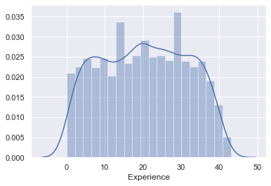

```python
sns.distplot(data['Experience'])
```

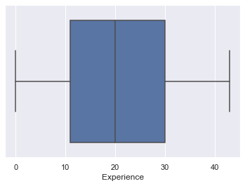

```python
sns.boxplot(data['Experience'])
```

# 3.3.4 INCOME

```python
print("The 5 point summary of income column would give the below results: ")
data['Income'].describe().T
```

```
The 5 point summary of income column would give the below results:
```

```
count    5000.000000
mean       73.774200
std        46.033729
min         8.000000
25%        39.000000
50%        64.000000
75%        98.000000
max       224.000000
Name: Income, dtype: float64
```

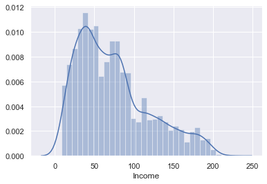

```python
sns.distplot(data['Income'])
```

Observation: Income Column is right skewed distributed

# 3.3.5 ZIPCODE

This column is about the zip code the customer resides or has his home in.

```python
print("The 5 point summary of zip code column would give the below results: ")
data['ZIP Code'].describe()
```

```
The 5 point summary of zip code column would give the below results:
```

```
count     5000.000000
mean     93152.503000
std       2121.852197
min       9307.000000
25%      91911.000000
50%      93437.000000
75%      94608.000000
max      96651.000000
Name: ZIP Code, dtype: float64
```

Let us see the top 5 areas which brought Personal Loan

```python
data[data['Personal Loan']==1]['ZIP Code'].value_counts().head(5)
```

```
94720    19
94305    13
92093     9
90095     8
90089     8
Name: ZIP Code, dtype: int64
```

Let us see the top 10 areas which brought Personal Loan

```python
data[data['Personal Loan']==1]['ZIP Code'].value_counts().head(10)
```

```
94720    19
94305    13
92093     9
90095     8
90089     8
94304     8
92182     7
94022     6
95051     6
95616     6
Name: ZIP Code, dtype: int64
```

# 3.3.6 Family

This column is about the no of members living in his family

```python
print("The 5 point summary of family column would give the below results: ")
data['Family'].describe()
```

```
The 5 point summary of family column would give the below results:
```

```
count    5000.000000
mean        2.396400
std         1.147663
min         1.000000
25%         1.000000
50%         2.000000
75%         3.000000
max         4.000000
Name: Family, dtype: float64
```

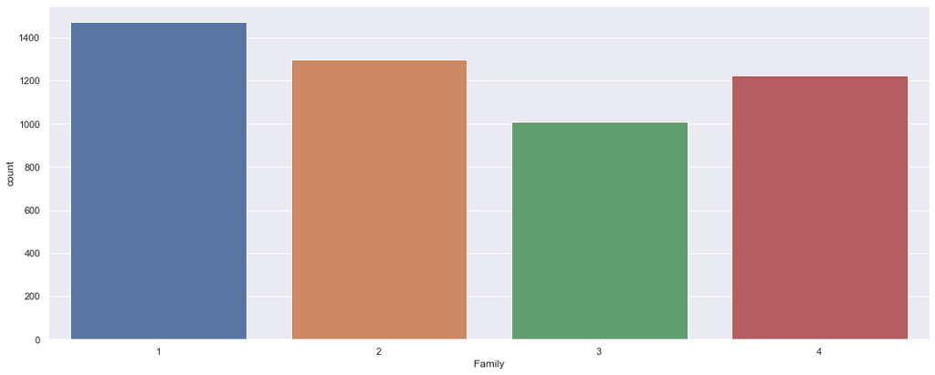

```python
plt.figure(figsize=(18,7))
sns.countplot(data['Family'])
```

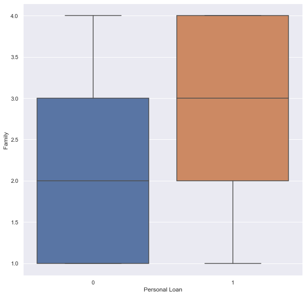

```python
plt.figure(figsize=(10,10))
sns.boxplot(y=data['Family'],x=data['Personal Loan'])
```

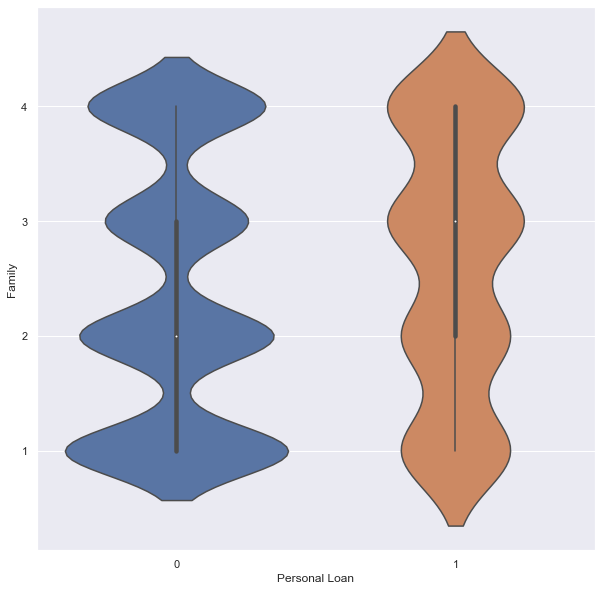

```python
plt.figure(figsize=(10,10))
sns.violinplot(y=data['Family'],x=data['Personal Loan'])
```

Observation: the plots above shows that higher sized family members bought personal loanLets do statistical analysis whether Family size is related to buying Personal Loan or not.

```python
print("Individual count of Family column: "," "*500, data['Family'].value_counts())
```

```
Individual count of Family column:                                                                                                                                                                                                                                                                          …
2    1296
4    1222
3    1010
Name: Family, dtype: int64
```

NULL HYPOTHESIS(H0): Family size is not related in buying Personal Loan

ALTERNATIVE HYPOTHESIS(Ha): Family size is related in buying Personal Loan

# Level of significance = 0.05

```python
null = 'Family size is not related in buying Personal Loan'
alternate = 'Family size is related in buying Personal Loan'
a=np.array(data[data['Personal Loan']==0]['Family'])
b=np.array(data[data['Personal Loan']==1]['Family'])
t_stat, p_value = stats.ttest_ind(a,b,axis=0)
print("the caluclated value of tstatistic is",t_stat)
print("The pvalue is",p_value)
print(""*1000)
print("Based on the statistical evidence")
if p_value > 0.05:
    print("we fail to reject null hypothesis as the p_value", p_value, "is greater than 0.05")
    print(null)
else:
    print("we reject null hypothesis as the p_value", p_value, "is less than 0.05")
    print(alternate)
```

```
the caluclated value of tstatistic is -4.34662958524817
The pvalue is 1.4099040685673807e-05

Based on the statistical evidence
we reject null hypothesis as the p_value 1.4099040685673807e-05 is less than 0.05
Family size is related in buying Personal Loan
```

# 3.3.7 CCAvg

```python
print("The 5 point summary of CCAvg column would give the below results: ")
data['CCAvg'].describe()
```

```
The 5 point summary of CCAvg column would give the below results:
```

```
count    5000.000000
mean        1.937938
std         1.747659
min         0.000000
25%         0.700000
50%         1.500000
75%         2.500000
max        10.000000
Name: CCAvg, dtype: float64
```

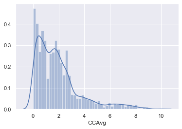

```python
sns.distplot(data['CCAvg'])
```

# 3.3.8 Education

This column is about the Level Of Education of the customer 1: Undergrad; 2: Graduate; 3: Advanced/Professional

```python
print("The 5 point summary of Education column would give the below results: ")
data['Education'].describe()
```

```
The 5 point summary of Education column would give the below results:
```

```
count    5000.000000
mean        1.881000
std         0.839869
min         1.000000
25%         1.000000
50%         2.000000
75%         3.000000
max         3.000000
Name: Education, dtype: float64
```

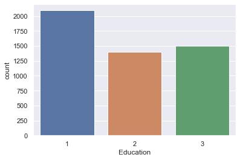

```python
sns.countplot(data['Education'])
```

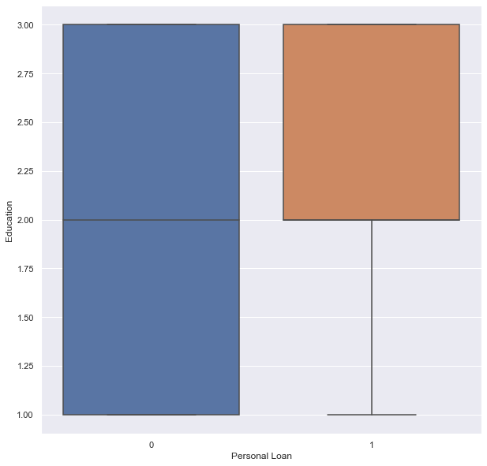

```python
plt.figure(figsize=(10,10))
sns.boxplot(y=data['Education'],x=data['Personal Loan'])
```

Observation: Those who took loan, much of them seems to be from highly educated background that is either graduate or professional ones.

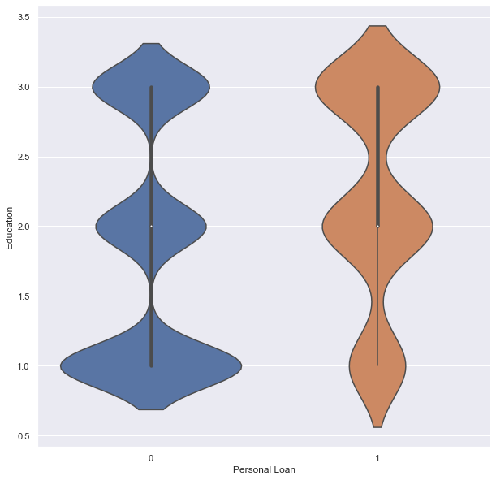

```python
plt.figure(figsize=(10,10))
sns.violinplot(y=data['Education'],x=data['Personal Loan'])
```

Lets do statistical analysis whether level of education is related in buying Personal Loan or not.Question: Is Level of Education related to buying personal loan ?

```python
print("Individual count of bmi column: "," "*500, data['Education'].value_counts())
```

```
Individual count of bmi column:                                                                                                                                                                                                                                                                             …
3    1501
2    1403
Name: Education, dtype: int64
```

NULL HYPOTHESIS(H0): Level of Education is not related in buying Personal Loan

ALTERNATIVE HYPOTHESIS(Ha): Level of Education is related in buying Personal Loan

# Level of significance = 0.05

```python
null = 'Level of Education is not related in buying Personal Loan'
alternate = 'Level of Education is related in buying Personal Loan'
a=np.array(data[data['Personal Loan']==0].Education)
b=np.array(data[data['Personal Loan']==1].Education)
t_stat, p_value = stats.ttest_ind(a,b,axis=0)
print("the caluclated value of tstatistic is",t_stat)
print("The pvalue is",p_value)
print(""*1000)
print("Based on the statistical evidence")
if p_value > 0.05:
    print("we fail to reject null hypothesis as the p_value", p_value, "is greater than 0.05")
    print(null)
else:
    print("we reject null hypothesis as the p_value", p_value, "is less than 0.05")
    print(alternate)
```

```
the caluclated value of tstatistic is -9.757366156256907
The pvalue is 2.70966319357669e-22

Based on the statistical evidence
we reject null hypothesis as the p_value 2.70966319357669e-22 is less than 0.05
Level of Education is related in buying Personal Loan
```

# 3.3.9 Mortgage

```python
print("The 5 point summary of Mortgage column would give the below results: ")
data['Mortgage'].describe()
```

```
The 5 point summary of Mortgage column would give the below results:
```

```
count    5000.000000
mean       56.498800
std       101.713802
min         0.000000
25%         0.000000
50%         0.000000
75%       101.000000
max       635.000000
Name: Mortgage, dtype: float64
```

Observation:

- Half the People dont have any House Mortgage

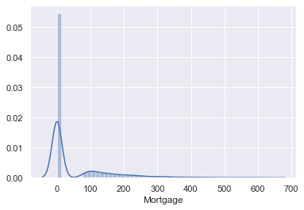

```python
sns.distplot(data['Mortgage'])
```

Observation:

- Mortgage column is right skewed distribution

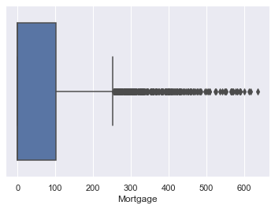

```python
sns.boxplot(data['Mortgage'])
```

Observation:

# 3.3.10 Personal Loan

This is the target variable, we need to predict and this column is about whether the customer has bought Personal Loan or not

```python
print("The 5 point summary of Personal Loan column would give the below results: ")
data['Personal Loan'].describe()
```

```
The 5 point summary of Personal Loan column would give the below results:
```

```
count    5000.000000
mean        0.096000
std         0.294621
min         0.000000
25%         0.000000
50%         0.000000
75%         0.000000
max         1.000000
Name: Personal Loan, dtype: float64
```

Observation:

- Most of them have not brought Personal Loan and this can be better visualized in Count plot below

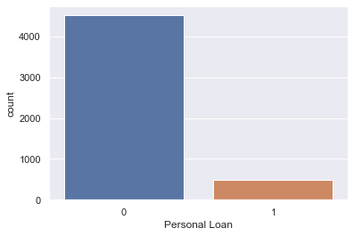

```python
sns.countplot(data['Personal Loan'])
```

This is y, which needs to be predicted by our ML Algorithms

# 3.3.11 Securities Account

This column is all about whether the customer has Securities Account or not

```python
print("The 5 point summary of Securities Account column would give the below results: ")
data['Securities Account'].describe()
```

```
The 5 point summary of Securities Account column would give the below results:
```

```
count    5000.000000
mean        0.104400
std         0.305809
min         0.000000
25%         0.000000
50%         0.000000
75%         0.000000
max         1.000000
Name: Securities Account, dtype: float64
```

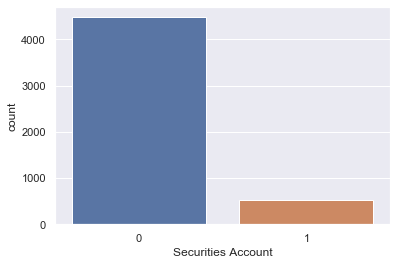

```python
sns.countplot(data['Securities Account'])
```

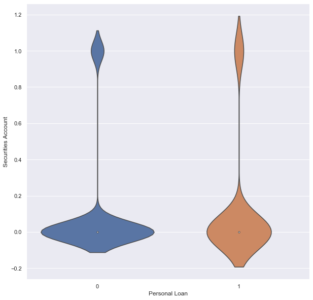

```python
plt.figure(figsize=(10,10))
sns.violinplot(y=data['Securities Account'],x=data['Personal Loan'])
```

oBSERVTION: There seems no relation whether the Securities Account holding will lead to buying Personal loanLets do statistical analysis whether Security Acccount holder is related to buying Personal Loan or not.

```python
print("Individual count of Securities Account column: "," "*500, data['Securities Account'].value_counts())
```

```
Individual count of Securities Account column:                                                                                                                                                                                                                                                              …
1     522
Name: Securities Account, dtype: int64
```

NULL HYPOTHESIS(H0): Securities Account holder is not related in buying Personal Loan

ALTERNATIVE HYPOTHESIS(Ha): Securities Account holder is related in buying Personal Loan

# Level of significance = 0.05

```python
null = 'Securities Account holder is not related in buying Personal Loan'
alternate = 'Securities Account holder is related in buying Personal Loan'
a=np.array(data[data['Personal Loan']==0]['Securities Account'])
b=np.array(data[data['Personal Loan']==1]['Securities Account'])
t_stat, p_value = stats.ttest_ind(a,b,axis=0)
print("the caluclated value of tstatistic is",t_stat)
print("The pvalue is",p_value)
print(""*1000)
print("Based on the statistical evidence")
if p_value > 0.05:
    print("we fail to reject null hypothesis as the p_value", p_value, "is greater than 0.05")
    print(null)
else:
    print("we reject null hypothesis as the p_value", p_value, "is less than 0.05")
    print(alternate)
```

```
the caluclated value of tstatistic is -1.5524375545579225
The pvalue is 0.12062087855564664

Based on the statistical evidence
we fail to reject null hypothesis as the p_value 0.12062087855564664 is greater than 0.05
Securities Account holder is not related in buying Personal Loan
```

# 3.3.12 CD Account

This column is all about whether the customer has CD Account or not

```python
print("The 5 point summary of CD Account column would give the below results: ")
data['CD Account'].describe()
```

```
The 5 point summary of CD Account column would give the below results:
```

```
count    5000.00000
mean        0.06040
std         0.23825
min         0.00000
25%         0.00000
50%         0.00000
75%         0.00000
max         1.00000
Name: CD Account, dtype: float64
```

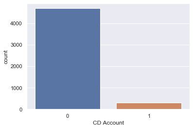

```python
sns.countplot(data['CD Account'])
```

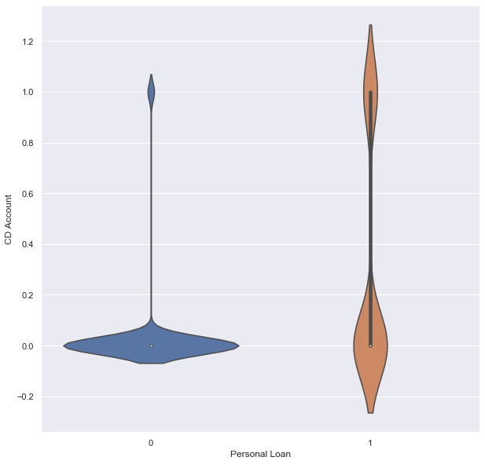

```python
plt.figure(figsize=(10,10))
sns.violinplot(y=data['CD Account'],x=data['Personal Loan'])
```

NULL HYPOTHESIS(H0): CD Account holder is not related in buying Personal Loan

ALTERNATIVE HYPOTHESIS(Ha): CD Account holder is related in buying Personal Loan

# Level of significance = 0.05

```python
null = 'CD Account holder is not related in buying Personal Loan'
alternate = 'CD Account holder is related in buying Personal Loan'
a=np.array(data[data['Personal Loan']==0]['CD Account'])
b=np.array(data[data['Personal Loan']==1]['CD Account'])
t_stat, p_value = stats.ttest_ind(a,b,axis=0)
print("the caluclated value of tstatistic is",t_stat)
print("The pvalue is",p_value)
print(""*1000)
print("Based on the statistical evidence")
if p_value > 0.05:
    print("we fail to reject null hypothesis as the p_value", p_value, "is greater than 0.05")
    print(null)
else:
    print("we reject null hypothesis as the p_value", p_value, "is less than 0.05")
    print(alternate)
```

```
the caluclated value of tstatistic is -23.576033174385408
The pvalue is 1.2784028484478752e-116

Based on the statistical evidence
we reject null hypothesis as the p_value 1.2784028484478752e-116 is less than 0.05
CD Account holder is related in buying Personal Loan
```

# 3.3.13 Online

This column is all about whether the customer uses internet banking or not

```python
print("The 5 point summary of Online column would give the below results: ")
data['Online'].describe()
```

```
The 5 point summary of Online column would give the below results:
```

```
count    5000.000000
mean        0.596800
std         0.490589
min         0.000000
25%         0.000000
50%         1.000000
75%         1.000000
max         1.000000
Name: Online, dtype: float64
```

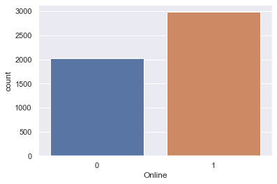

```python
sns.countplot(data['Online'])
```

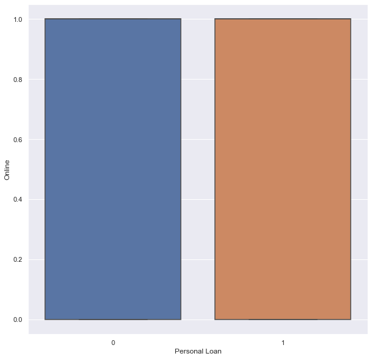

```python
plt.figure(figsize=(10,10))
sns.boxplot(y=data['Online'],x=data['Personal Loan'])
```

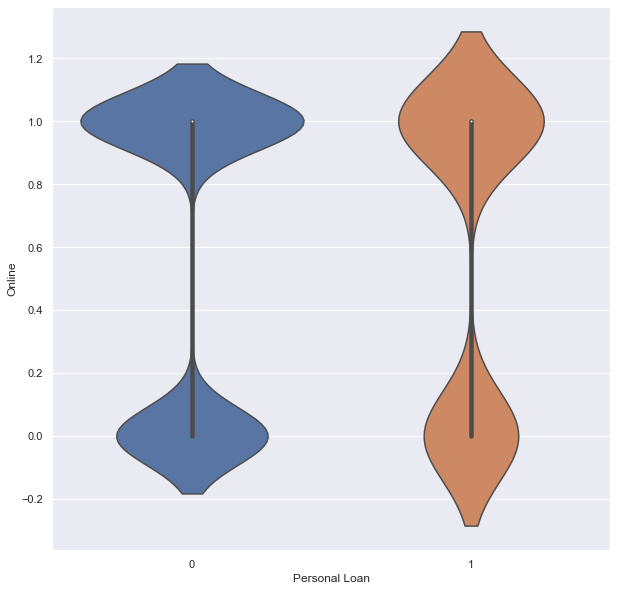

```python
plt.figure(figsize=(10,10))
sns.violinplot(y=data['Online'],x=data['Personal Loan'])
```

Observation: There seems no relation whether online banking users and buying Personal Loan as they overlap Lets do statistical analysis whether Internet banking usage is related to buying Personal Loan or not.

```python
print("Individual count of Online column: "," "*500, data['Online'].value_counts())
```

```
Individual count of Online column:                                                                                                                                                                                                                                                                          …
0    2016
Name: Online, dtype: int64
```

NULL HYPOTHESIS(H0): Internet banking usage is not related in buying Personal Loan

ALTERNATIVE HYPOTHESIS(Ha): Internet banking usage is related in buying Personal Loan

# Level of significance = 0.05

```python
null = 'Internet banking usage is not related in buying Personal Loan'
alternate = 'Internet banking usage is related in buying Personal Loan'
a=np.array(data[data['Personal Loan']==0]['Online'])
b=np.array(data[data['Personal Loan']==1]['Online'])
t_stat, p_value = stats.ttest_ind(a,b,axis=0)
print("the caluclated value of tstatistic is",t_stat)
print("The pvalue is",p_value)
print(""*1000)
print("Based on the statistical evidence")
if p_value > 0.05:
    print("we fail to reject null hypothesis as the p_value", p_value, "is greater than 0.05")
    print(null)
else:
    print("we reject null hypothesis as the p_value", p_value, "is less than 0.05")
    print(alternate)
```

```
the caluclated value of tstatistic is -0.44382853915376774
The pvalue is 0.6571857663873077

Based on the statistical evidence
we fail to reject null hypothesis as the p_value 0.6571857663873077 is greater than 0.05
Internet banking usage is not related in buying Personal Loan
```

# 3.3.14 Credit card

This column is all about whether the user uses the Cresit Card issued by Universal bank or not

```python
print("The 5 point summary of Credit card column would give the below results: ")
data['CreditCard'].describe()
```

```
The 5 point summary of Credit card column would give the below results:
```

```
count    5000.000000
mean        0.294000
std         0.455637
min         0.000000
25%         0.000000
50%         0.000000
75%         1.000000
max         1.000000
Name: CreditCard, dtype: float64
```

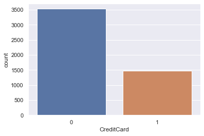

```python
sns.countplot(data['CreditCard'])
```

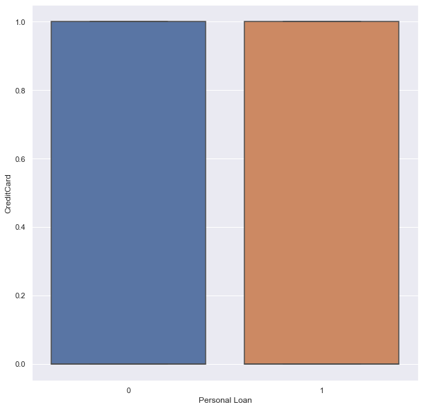

```python
plt.figure(figsize=(10,10))
sns.boxplot(y=data['CreditCard'],x=data['Personal Loan'])
```

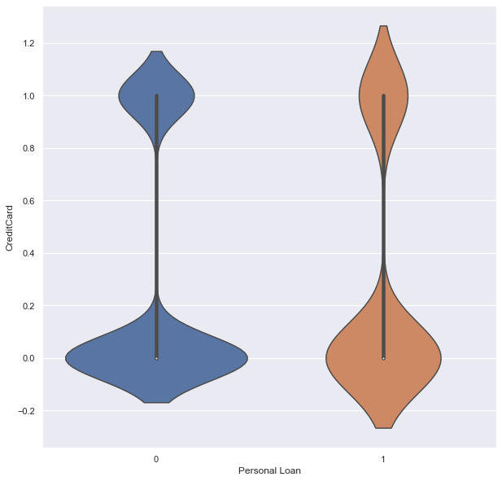

```python
plt.figure(figsize=(10,10))
sns.violinplot(y=data['CreditCard'],x=data['Personal Loan'])
```

Observation: There seems no relation whether CreditCard users and buying Personal Loan as they overlap Lets do statistical analysis whether CreditCard holder is related to buying Personal Loan or not.

```python
print("Individual count of CreditCard column: "," "*500, data['CreditCard'].value_counts())
```

```
Individual count of CreditCard column:                                                                                                                                                                                                                                                                      …
1    1470
Name: CreditCard, dtype: int64
```

NULL HYPOTHESIS(H0): CreditCard holder is not related in buying Personal Loan

ALTERNATIVE HYPOTHESIS(Ha): CreditCard holder is related in buying Personal Loan

# Level of significance = 0.05

```python
null = 'CreditCard holder is not related in buying Personal Loan'
alternate = 'CreditCard holder is related in buying Personal Loan'
a=np.array(data[data['Personal Loan']==0]['CreditCard'])
b=np.array(data[data['Personal Loan']==1]['CreditCard'])
t_stat, p_value = stats.ttest_ind(a,b,axis=0)
print("the caluclated value of tstatistic is",t_stat)
print("The pvalue is",p_value)
print(""*1000)
print("Based on the statistical evidence")
if p_value > 0.05:
    print("we fail to reject null hypothesis as the p_value", p_value, "is greater than 0.05")
    print(null)
else:
    print("we reject null hypothesis as the p_value", p_value, "is less than 0.05")
    print(alternate)
```

```
the caluclated value of tstatistic is -0.1980577438859699
The pvalue is 0.8430079402001929

Based on the statistical evidence
we fail to reject null hypothesis as the p_value 0.8430079402001929 is greater than 0.05
CreditCard holder is not related in buying Personal Loan
```